# FinalProject: honey production between temperature and number of bee colonies

# Introduction

Welcome to data science tutorial using R code. In this project, I will explore two factors that may affect honey production in the US. The two factors are temperature and the number of honey bee colonies. In the last few years, there was a rapid decline in honey production worldwide. In recent years, honey production of some other countries is recovering, but American honey industry is still struggling. So we will find out the importantce of temperature and number of honey bee colonies.

# Content

1. Data preparation and scraping
2. Exploratory data analysis
3. Machine learning

# Getting started

We need to install all the libraries we need for this tutorial.  
tidyverse <- a collection of tools ease the process of data science  
dplyr <- a library inside tidyverse  
rvest <- useful for web scraping  
ggplot2 <- help us visualise the datas  
cvTools <- for cross validation  
robustbase <- a base library required by cvTools  
broom <- interpretate regression result

```r
library(tidyverse)
library(dplyr)
library(rvest)
```

```r
library(ggplot2)
library(cvTools)
library(robustbase)
library(broom)
```

# Data preparation and scraping

Upload the honey production data from https://www.kaggle.com/jessicali9530/wrangling-the-honey-production-dataset/data. This data is in csv form. It contains honey production for most of the states from 1998 to 2012. The weight unit is pound, and currency is dollars. There are eight attributes:  
state: state name  
numcol: number of honey producing colonies  
yieldpercol: honey yield per colony  
totalprod: total production(numcol x yieldpercol)  
stocks: stocks held by producers  
priceperlb: average price per pound  
prodvalue: value of production(totalprod x priceperlb)  
year: year of the production

We use read_csv() function here to read the data we download and it will automatically convert into a data.frame type, which is a data structure consists of attributes(columns) and entities(rows).

```r
honey <- read_csv("/Users/Grace/Desktop/honey-production/honeyproduction.csv")
honey%>%head() #head() function returns the first part of the data
```

```
## # A tibble: 6 x 8
##   state numcol yieldpercol totalprod   stocks priceperlb prodvalue  year
##   <chr>  <dbl>       <int>     <dbl>    <dbl>      <dbl>     <dbl> <int>
## 1 AL     16000          71   1136000   159000      0.720    818000  1998
## 2 AZ     55000          60   3300000  1485000      0.640   2112000  1998
## 3 AR     53000          65   3445000  1688000      0.590   2033000  1998
## 4 CA    450000          83  37350000 12326000      0.620  23157000  1998
## 5 CO     27000          72   1944000  1594000      0.700   1361000  1998
## 6 FL    230000          98  22540000  4508000      0.640  14426000  1998
```

Now we need to upload another data. Scrape the average annual temperature for every state from 1998 to 2012. We scrape the data from https://www.ncdc.noaa.gov/cag/statewide/time-series/.

At this time, the rvest library becomes handy. We will use read_html() function to help us read a web URL and get the webpage contents and html_nodes() to find the table we want.

In this dataset, The attribute Dates represents the year and month. Value is the temperature in Fahrenheit. And state_name represents state.

```r
annual_temperature_statewise<-data.frame(Dates=character(),Value=character())
for(i in 1:50){
  if(i==49){ break}
  url<-paste("https://www.ncdc.noaa.gov/cag/statewide/time-series/",as.character(i),"/tavg/12/12/1998-2012?base_prd=true&firstbaseyear=1901&lastbaseyear=2000",sep="")
  doc<-read_html(url) #read the webpage contents from the URL
  location<-paste("#state > option:nth-child(",as.character(i),")",sep="") #find the table we want using CSS selector style
  state<-doc%>%html_nodes(location)%>%html_text() #we need to find out which state this table belongs to, so we use html_text() to read the text content of the node contains state name
  table<-doc%>%html_nodes("#valuesTable")%>%html_table()%>%
    as.data.frame()%>%select(Dates,Value)%>%mutate(state_name=state)#now we transform the table into a data frame and select columns we need
  annual_temperature_statewise<-rbind(annual_temperature_statewise,table)#We combine the annual temperature data for each state into a whole data frame for convenience purpose
}
annual_temperature_statewise%>%head()
```

```
##             Dates  Value state_name
## 1 199801 - 199812 65.1°F    Alabama
## 2 199901 - 199912 64.1°F    Alabama
## 3 200001 - 200012 63.6°F    Alabama
## 4 200101 - 200112 63.0°F    Alabama
## 5 200201 - 200212 63.6°F    Alabama
## 6 200301 - 200312 62.7°F    Alabama
```

Now have a look at two dataset we have: annual_temperature_statewise and honey. They both have year and state name. However, the Dates and state_name in annual_temperature_statewise are in different data representations. So we need to change the state name to its abbreviation, and change the Dates to Years. We use state.abb and state.name here which are built-in dictionaries that can help us perfrom transformation between state abbreviation and full name.

```r
new_temperature_statewise<-annual_temperature_statewise%>%
  mutate(state=state.abb[match(state_name,state.name)])
new_temperature_statewise<-new_temperature_statewise%>%
  separate(Dates,into = c("year","Months"),sep=4)%>%
  mutate(temperature=Value)%>% #We use sep=4 to indicate the index we want to separate
  select(-Months,-state_name,-Value)

new_temperature_statewise%>%head()
```

```
##   year state temperature
## 1 1998    AL      65.1°F
## 2 1999    AL      64.1°F
## 3 2000    AL      63.6°F
## 4 2001    AL      63.0°F
## 5 2002    AL      63.6°F
## 6 2003    AL      62.7°F
```

In this step, we are going to join honey production dataset and temperature dataset based on year and state name. In data science, there is a very convenience technique called join. We can join different table together based on matching columns. There are different type of joins, such as inner join, left join and so on. In our case, only states that are presented in both table are retained, which is a inner join. Here we change the temperature attribute to numeric type. For convenience, we also change year to a date data type.

```r
honey_temp <- merge(new_temperature_statewise, honey, by=c("state","year"))%>%as.data.frame()%>%
  mutate(temperature=substr(temperature,1,4))%>% #Since we want to do computation later on, we have to use the numeric part of the temperature only.We use substr() method here to extract the temmperature from the original strings.
  type_convert(cols(year=col_date("%Y"),temperature=col_number()))#use type convert to convert year to date data type and temperature to numeric data type

honey_temp%>%head()
```

```
##   state       year temperature numcol yieldpercol totalprod stocks
## 1    AL 1998-01-01        65.1  16000          71   1136000 159000
## 2    AL 1999-01-01        64.1  17000          68   1156000 185000
## 3    AL 2000-01-01        63.6  16000          78   1248000 187000
## 4    AL 2001-01-01        63.0  14000          73   1022000 235000
## 5    AL 2002-01-01        63.6  12000          86   1032000 103000
## 6    AL 2003-01-01        62.7  13000          82   1066000  43000
##   priceperlb prodvalue
## 1       0.72    818000
## 2       0.56    647000
## 3       0.59    736000
## 4       0.72    736000
## 5       1.18   1218000
## 6       1.24   1322000
```

# Exploratory Data Analysis

The goal of exploratory data analysis is to analyze the data we have and helps us to make decisions about appropriate methods. We are going to perform an exploration of attribute variables and entity observations.

At this time we are using ggplot() function which is powerful at making different plots. We specify +geom_point() to make scatter plot, it is very useful to visualise the relationship between two variables.

First we create a plot showing total production vs year. From this plot, as the year increases, the total production each year for each state didn’t increase. It seems that there is no obvious relation between the two. Since we mixed all the states together, there maybe exists a trend for a single state. So we move on to the next plot to see trends for separate state.

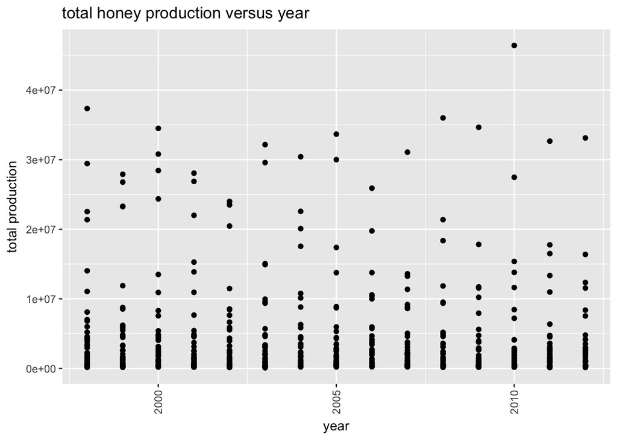

```r
honey_temp%>%ggplot(mapping = aes(y=totalprod,x=year)) + geom_point()+theme(axis.text.x = element_text(angle=90, vjust=0.5))+
  labs(title="total honey production versus year",y="total production",x="year")
```

In this plot, we continue to explore the relationship between year and total production. At first glance it looks like a cluster, but we can create color to indicate the states. We also add a regression line for each state. From this plot, as the year increases, some states’ total prodection of honey increase and some of them decrease. Now we want to find out the reason of decreasing and increasing of honey production.

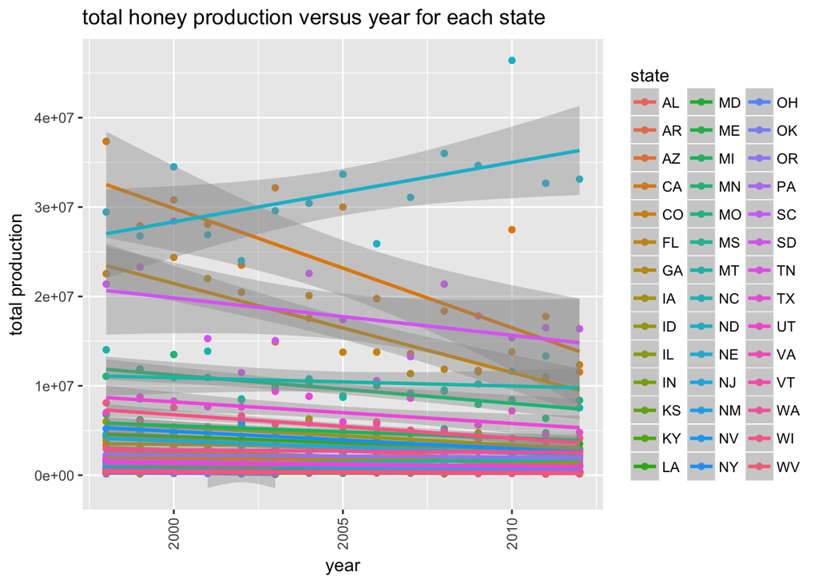

```r
honey_temp%>%ggplot(mapping = aes(y=totalprod,x=year,color=state)) +
  geom_point() + theme(axis.text.x = element_text(angle=90, vjust=0.5))+geom_smooth(method=lm)+
  labs(title="total honey production versus year for each state",y="total production",x="year")
```

We want to plot a plot for temperature versus year to see if we can find any similiar pattern. If there exist a pattern which is similiar to the previous plot, that means there may exist a relationship between temperature and honey production.

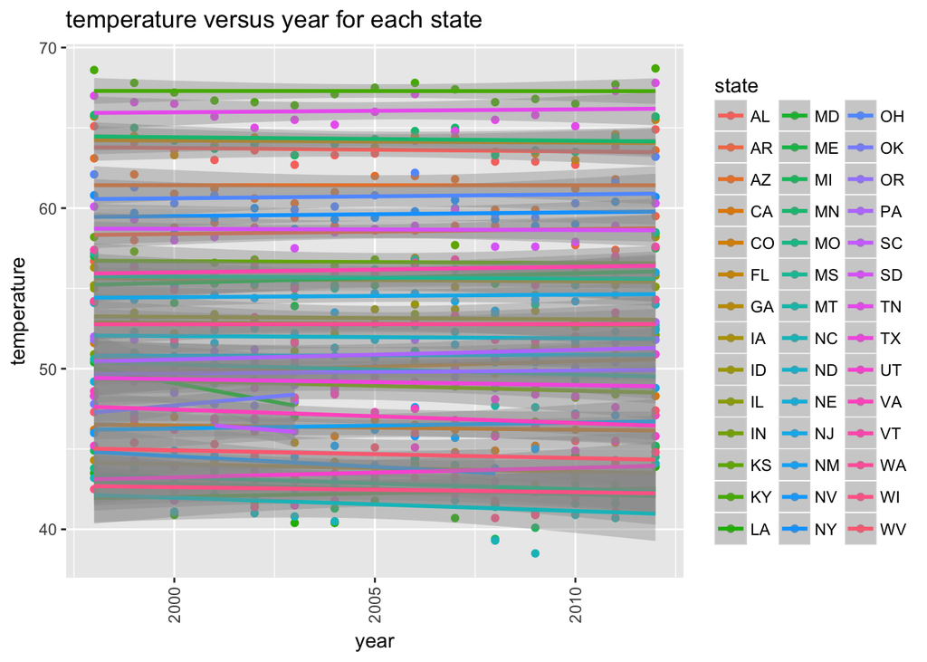

```r
honey_temp%>%ggplot(mapping = aes(y=temperature,x=year,color=state)) +
  geom_point() + theme(axis.text.x = element_text(angle=90, vjust=0.5))+geom_smooth(method=lm)+
  labs(title="temperature versus year for each state",y="temperature",x="year")
```

Well, by looking at this plot, the temperature seems to be very stable for each state. This looks different from the total producation versus year plot. But this doesn’t necessarily mean that there are no relationship between honey production and temperature. In our next plot, we want to plot directly between total honey production and temperature.

This is a plot of temperature vs total production.

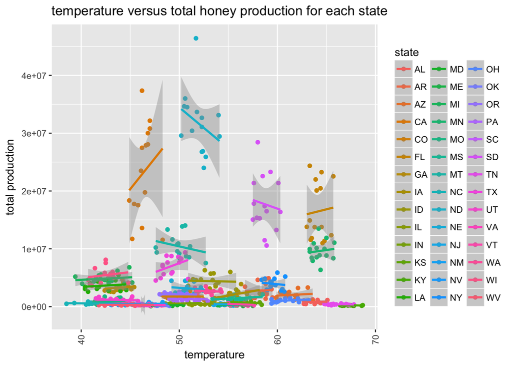

```r
honey_temp%>%ggplot(mapping = aes(y=totalprod,x=temperature,color=state)) + geom_point() + theme(axis.text.x = element_text(angle=90, vjust=0.5))+geom_smooth(method=lm) + labs(title="temperature versus total honey production for each state",y="total production",x="temperature")
```

The plot itself still looks like a cluster. The production for each state sometimes is increasing with temperature and sometimes is decreasing. There maybe other factors that are affecting our relationships. We want to see generally if there exist relationship between temperature and honey production, so we will find centrol tendency (use mean at this time) of these two variables and plot them.

Here we plot the mean of temperature vs mean of total production of all states for each year in order to see the general trend. From the regression line, we could see the mean of total producton slightly decreases as the mean temperature increases.

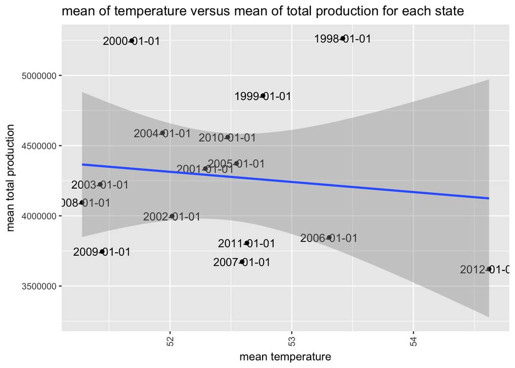

```r
honey_temp%>%group_by(year)%>%
  summarise(mean_total_prod=mean(totalprod),mean_temperature=mean(temperature))%>%#we use group by year to calculate mean of total production and temperature for each year
  ggplot(mapping = aes(y=mean_total_prod,x=mean_temperature,label=year)) + geom_point() + theme(axis.text.x = element_text(angle=90, vjust=0.5))+geom_text()+geom_smooth(method=lm) +
  labs(title="mean of temperature versus mean of total production for each state",y="mean total production",x="mean temperature") #we use labels here to see the year of the data point
```

There seems to exist a relationship now! But there are few outliers. Outliers are data points that are far away from our main group of data, and they will cause our model becomes unfair. So we need to remove them.

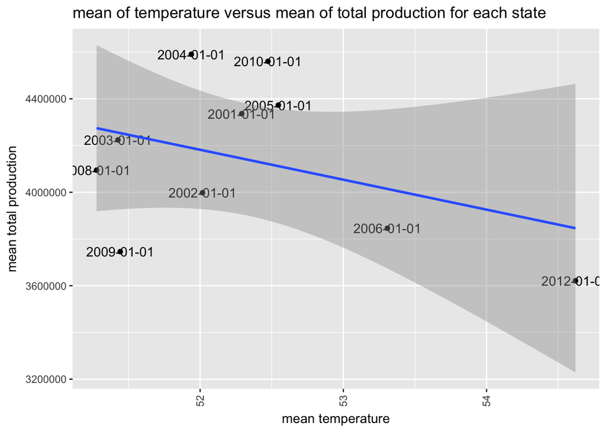

```r
honey_temp<-honey_temp%>%filter(!as.character(year) %in% c("1998-01-01","1999-01-01","2000-01-01","2007-01-01","2011-01-01"))
honey_temp%>%group_by(year)%>%
  summarise(mean_total_prod=mean(totalprod),mean_temperature=mean(temperature))%>%#we use group by year to calculate mean of total production and temperature for each year
  ggplot(mapping = aes(y=mean_total_prod,x=mean_temperature,label=year)) + geom_point() +
  theme(axis.text.x = element_text(angle=90, vjust=0.5))+geom_text()+geom_smooth(method=lm) +
  labs(title="mean of temperature versus mean of total production for each state",y="mean total production",x="mean temperature") #we use labels here to see the year of the data point
```

Now the plot looks nicer without the outliers. Although there are still some data points that is away from the main data group, there are not too far away so we can ignore them.

We want to see the relationship between number of bee colonies vs year.

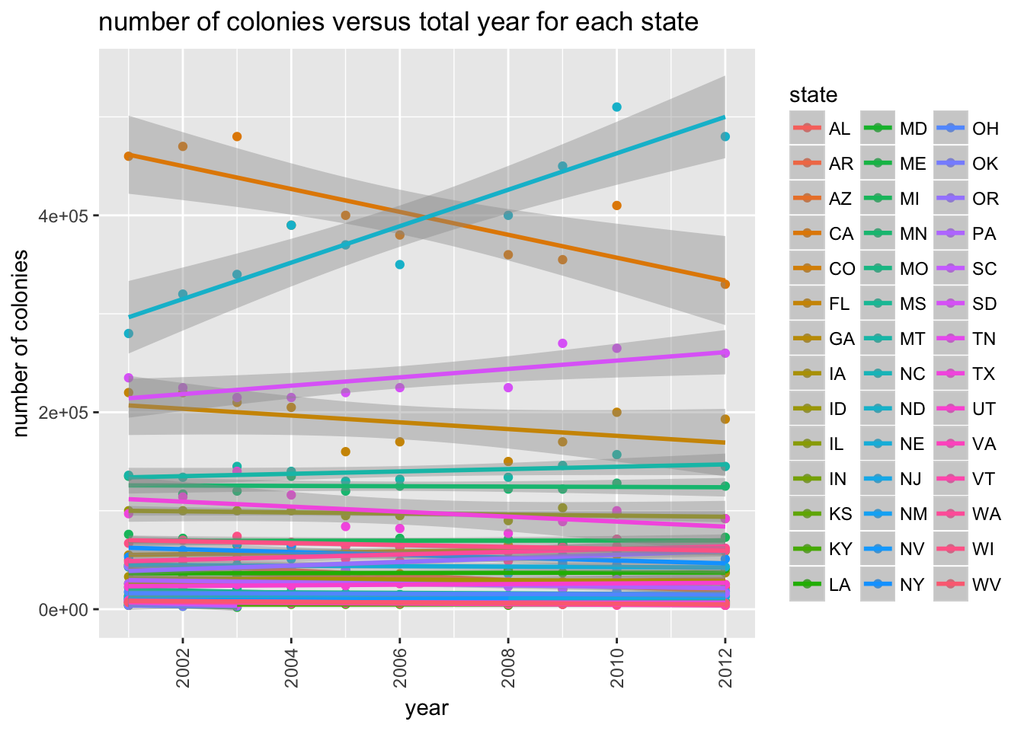

```r
honey_temp%>%ggplot(mapping = aes(y=numcol,x=year,color=state)) +
  geom_point() +
  theme(axis.text.x = element_text(angle=90, vjust=0.5))+
  geom_smooth(method=lm)+
  labs(title="number of colonies versus total year for each state",x="year",y="number of colonies")
```

We start to plot the number of bee colonies vs total production.

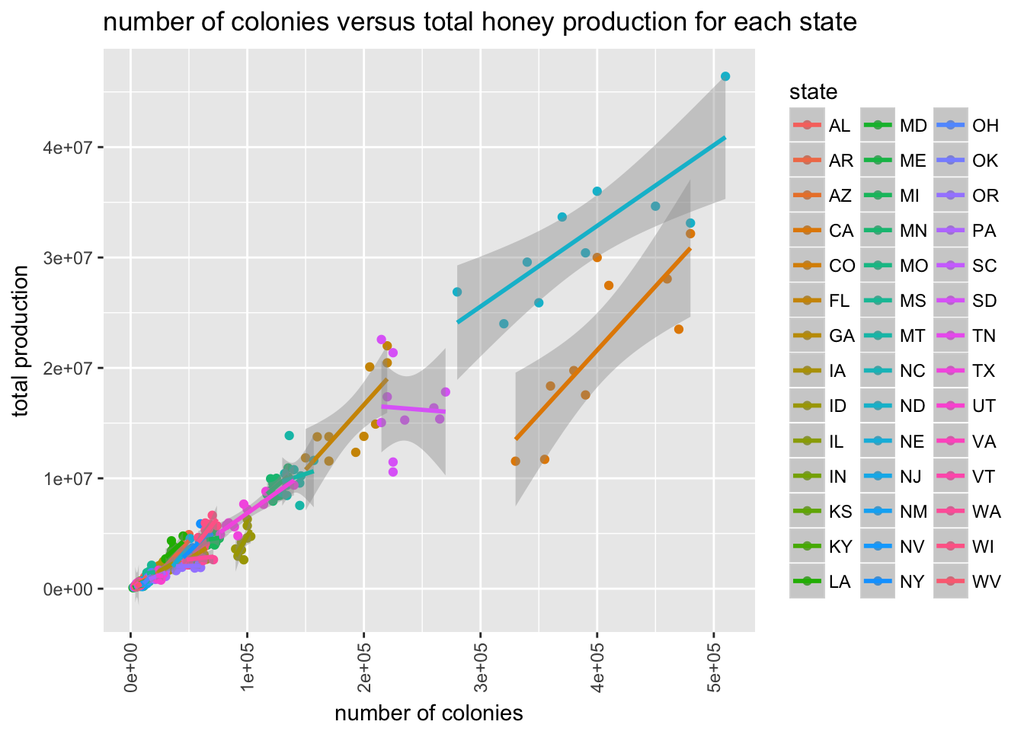

```r
honey_temp%>%ggplot(mapping = aes(y=totalprod,x=numcol,color=state)) +
  geom_point() +
  theme(axis.text.x = element_text(angle=90, vjust=0.5))+
  geom_smooth(method=lm)+
  labs(title="number of colonies versus total honey production for each state",y="total production",x="number of colonies")
```

We see a very clear trend in this plot that with the increase of number of colonies, the total honey production increases. This indicate that there exist a relationship between number of colonies and honey production.

We want to see the relaitonship in terms of central tendency again.

The following is a plot of the mean of total production vs mean of numer of colonies of all states for each year in order to see the general trend. From this plot, the mean of total production increases as the mean of number of bee colonies increases.

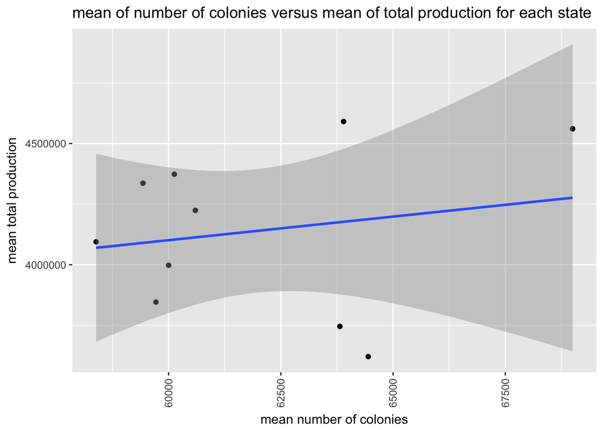

```r
honey_temp%>%group_by(year)%>%
  summarise(mean_total_prod=mean(totalprod),mean_numcol=mean(numcol))%>%
  ggplot(mapping = aes(y=mean_total_prod,x=mean_numcol)) +
  geom_point() + theme(axis.text.x = element_text(angle=90, vjust=0.5))+geom_smooth(method=lm)+
  labs(title="mean of number of colonies versus mean of total production for each state",y="mean total production",x="mean number of colonies")
```

We also want to see if there exists a relationship between number of bee colonies and temperature. If there is, this may suggest that a interaction between our predictors exists.

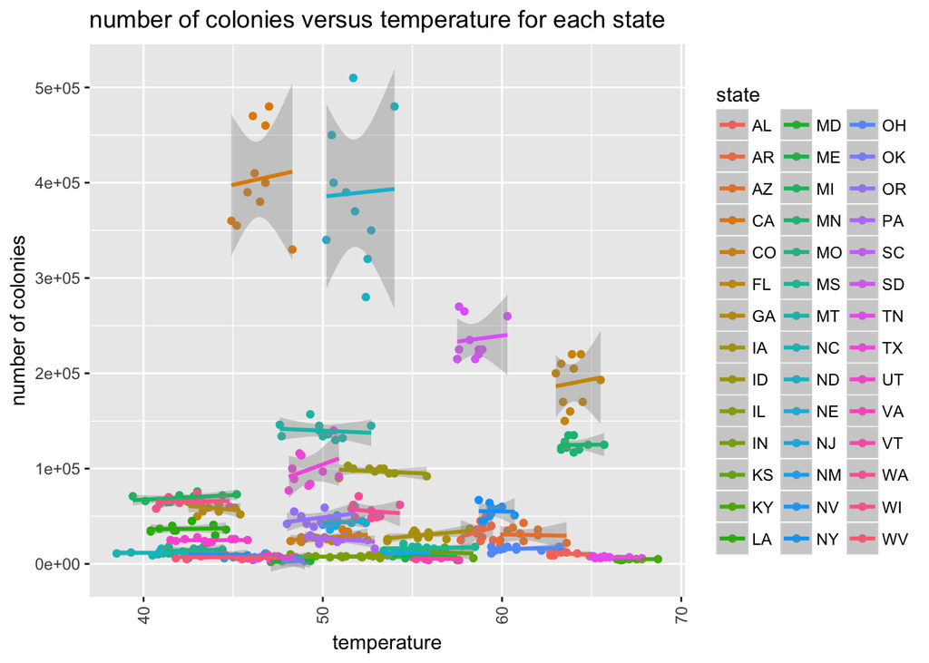

```r
honey_temp%>%ggplot(mapping = aes(y=numcol,x=temperature,color=state)) +
  geom_point() +
  theme(axis.text.x = element_text(angle=90, vjust=0.5))+
  geom_smooth(method=lm)+
  labs(title="number of colonies versus temperature for each state",x="temperature",y="number of colonies")
```

There doesn’t seem to exist a linear relationship between temperature and number of colonies.

# Machine Learning

Now it is time to generate a formula for our relationships. In this case, we use linear regression which is basically looking for a linear relationship between variables. Once we establish the model, we can give the model data and let it make predictions on the outcome.

## Hypothesis testing

In statistics data science hypothesis testing is very useful. During the hypothesis, we are testing a statistical relationship between the variables. First we need a null hypothesis: H0: There doesn’t exist a relationship between honey production and temperature, number of colonies.

We also need an alternative hypothesis when we reject null hypothesis:

Ha: There exists a relationship between honey production and temperature, number of colonies.

## Fit a linear regression model

We started to fit linear regression model at this time. We use lm function to accomplish this, but first we need to specify our relationship formula. A general linear regression formula is $Y=\beta_0+\beta_1X$, where these two beta are constants.In our case, the linear model should be $Total honey production=\beta_0+\beta_1*temperature+\beta_2*number of colonies$

```r
honey_fit <- lm(totalprod~1+temperature+numcol, data=honey_temp)
honey_fit %>% tidy() #we use tidy() function here to help us interpret the result
```

```
##          term      estimate    std.error statistic       p.value
## 1 (Intercept) -1.855068e+06 6.894348e+05 -2.690708  7.434297e-03
## 2 temperature  3.198563e+04 1.300834e+04  2.458856  1.436830e-02
## 3      numcol  6.987268e+01 1.014515e+00 68.872991 1.878702e-221
```

Let’s take a look at the linear regression result. The p-value here will tell us whether we should reject null hypothesis or not. When p-value is very small(commonly less than 0.05), we say that it is significant and thus we can reject the null hypothesis. For temperature, the p-value is 0.014, which is very small, so we can say that there exist a relationship between temperature and honey production. And for the number of colonies, the p-value is extreme significant, we should conclude that there exists a strong relationship between number of colonies and honey production.

Now we have found our regression model. But how is its performance? We use plots again.

Residual is the difference between our prediction and actual outcome, so when we plot residual, it should be center around 0 to indicate that our prediction is very close to the actual outcome.

First we plot residual versus temperature. ## Residual over temperature

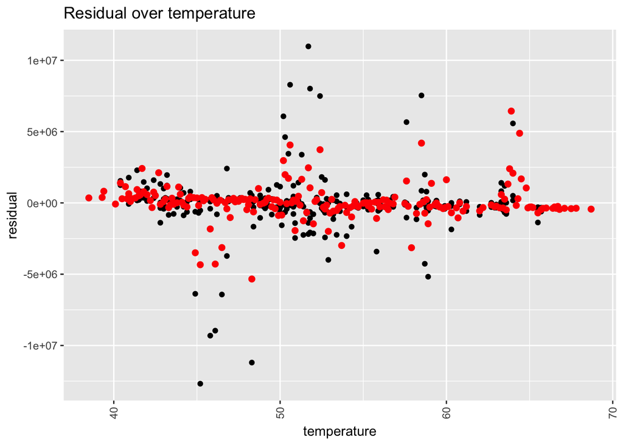

```r
augmented_honey <- honey_fit %>% augment() #use augment() function to get residuals
augmented_honey %>% ggplot(mapping=aes(x=temperature,y=.resid))+
  geom_point()+
   labs(title="Residual over temperature",
         x ="temperature",
         y = "residual")+
         stat_summary(fun.y=mean, geom="point", size=2, color="red") + theme(axis.text.x = element_text(angle=90, vjust=0.5))
```

By looking at the plot we can see that residual is center around 0 and most of the residuals are linear against temperature, which means our model is a good fit.

## residual over number of colonies

We also have to plot residual against our another predictors : number of colonies.

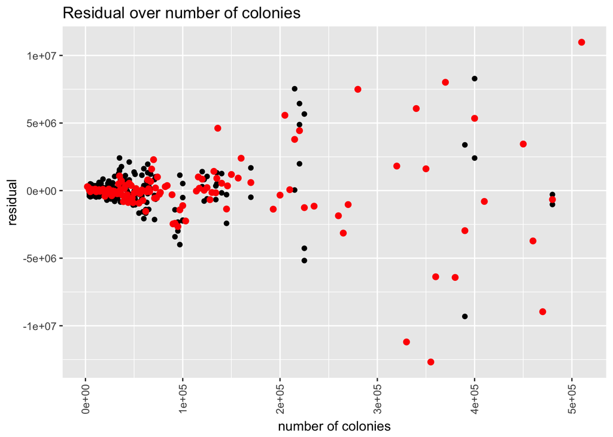

```r
augmented_honey %>% ggplot(mapping=aes(x=numcol,y=.resid))+geom_point()+
   labs(title="Residual over number of colonies",
         x = "number of colonies",
         y = "residual")+
         stat_summary(fun.y=mean, geom="point", size=2, color="red") + theme(axis.text.x = element_text(angle=90, vjust=0.5))
```

This doesn’t look good. The residual is centering around 0 at first but later on it becomes scattered.This indicates that there might exist Heteroscedasticity, which means residual gets larger as the number of colonies grows. To fix this, we need to make a transformation for number of colonies.

First we can try out log transformation. Log transformation is very useful for data transformation as it can make highly skewed distributions less skewed. We want to see the residual plot again to check its performence.

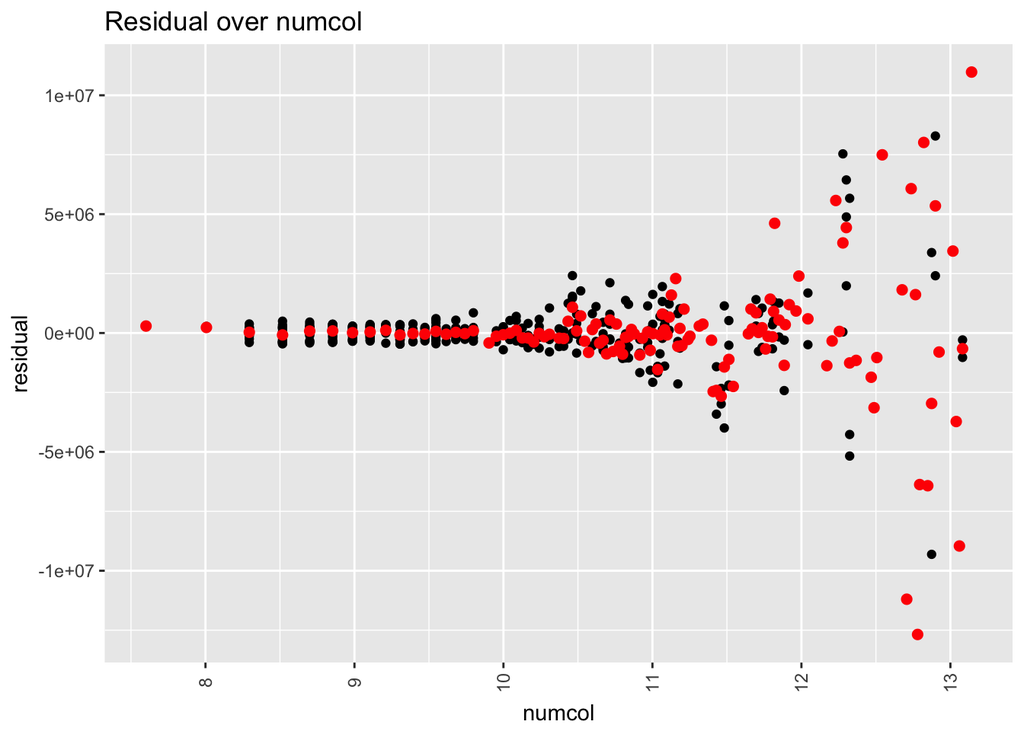

```r
augmented_honey %>% ggplot(mapping=aes(x=log(numcol),y=.resid))+geom_point()+
   labs(title="Residual over numcol",
         x = "numcol",
         y = "residual")+
         stat_summary(fun.y=mean, geom="point", size=2, color="red") + theme(axis.text.x = element_text(angle=90, vjust=0.5))
```

Looks not bad. The residual is more centered around 0 than the previous model. But at the end it still becomes scattered, which means our model may become unstable when number of colonies grows larger.

There are other transformation we can use, like take a square or square root of the variable. Feel free to try it out yourself to see its perfermence! Right now log transformation seems to have the best result.

Below is a square transformation of the number of colonies.

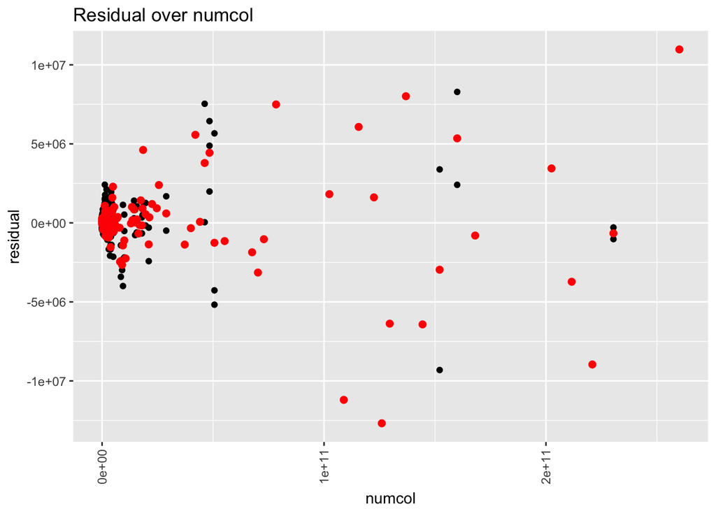

```r
augmented_honey %>% ggplot(mapping=aes(x=(numcol)^2,y=.resid))+geom_point()+
   labs(title="Residual over numcol",
         x = "numcol",
         y = "residual")+
         stat_summary(fun.y=mean, geom="point", size=2, color="red") + theme(axis.text.x = element_text(angle=90, vjust=0.5))
```

The residual becomes more randomly scattered, so we shouldn’t use this as our model.

## 10 fold cross validation

## overfitting

In our previous example, we are testing our predictions using the data we trained. Things might have changed if we perform predictions against other data. Now we should introdue the concept overfitting, which means the model is very closely fit to a single data. To avoid this, we should use k-fold crossvalidation to check the performence of our model.

## k-fold crossvalidation

k-fold crossvalidation is one of the most commonly used model validation approach. The basic idea is partition our data into k groups, and we will train our data on each of the k groups while at the same time we test our predictions on other k-1 groups. By using k-fold crossvalidation, we have reduced the size and the variance of the test data we have to predict.

We use cvFolds and cvLm to perform our crossvalidation to compare the performence of our original model and log transformed model.

```r
set.seed(1234) #set seed for reproducibility

folds <- cvFolds(nrow(honey_temp), K = 10) #create 10 folds

fitLm <- lm(totalprod~temperature+numcol, data = honey_temp) #the original model fit

cvLm(fitLm, cost = rtmspe, folds = folds) #perform 10 fold cross validation for linear regression
```

```
## 10-fold CV results:
##       CV
## 323008.8
```

```r
set.seed(1234) #set seed for reproducibility

folds <- cvFolds(nrow(honey_temp), K = 10)

honey_log <- honey_temp%>%mutate(numcol=log(numcol)) #the log transformed version of our dataset

fitLm <- lm(totalprod~temperature+numcol, data = honey_log) #the log transformed model

cvLm(fitLm, cost = rtmspe, folds = folds)
```

```
## 10-fold CV results:
##      CV
## 2044872
```

The results are prediction errors, the less the error the better the model. As we can see the prediction error for log transformed model is way larger than our original model, so we shouldn’t use log transformed model. We should keep our original model: $Honey_total_production=\beta_0+\beta_1*temperature+\beta_2*number of colonies$

# Conclusion

In conclusion, there does exist a relationship between honey total production and temperature, number of colonies. But the problem is, as the number of colonies grow larger, our prediction also becomes unstable. This happens a lot in exploring the relationship, the reason is there may exist other factors we don’t know yet that can have impacts on honey production, such as wind or the growth of the flowers. Unfortunately, I can only find very limit data related to other factors. We should keep in mind that we should always make more experiments to discover and test the relationship, there may exist more factors than we thought.

reference 1. http://onlinestatbook.com/2/transformations/log.html